# Project Assignment- Weight lifting Data Analysis Report

Pham Khanh

Tuesday, August 18, 2015

## Introduction

This project aims to use the data from accelerometers on the belt, forearm, arm, and dumbell of 6 participants to predict the manner in which they do the weight lifting. This is a typical classification problem where the quality weight lifting manner are classified into 5 type : A,B, C,D and E stored in the variable “classe” of training set.

## Library in use

```r
library(caret)
```

```r
library(rpart)
library(rpart.plot)
library(randomForest)
```

### Read the Data

After downloaded from the source, the data is loaded into 2 dataframes.

```r
train_raw <- read.csv("pml-training.csv")
test_raw <- read.csv("pml-testing.csv")
#View(train_raw)
#View(test_raw)
```

### Preprocessing

Exploting the training data set, we can observe that following variables are not useful for the study: + There are variables with a lot of missing values; + There are variables which are almost constant across observations; + The experiments for each group of classes in training set is ordered by time; therefore, any of variables indicating the order of observation are highly correlated with the classe. Including any of them in the model will provide a high accuracy result but not reflect the essence of our study, an example is given in the plot for variable X with color by classe. This type of ordering variables includes “X”, “raw_timestamp_part_1”, “cvtd_timestamp” and “num_window”. Similarly, the “user” variable will not available in the general context, so we shouldn’t use it as predictor.

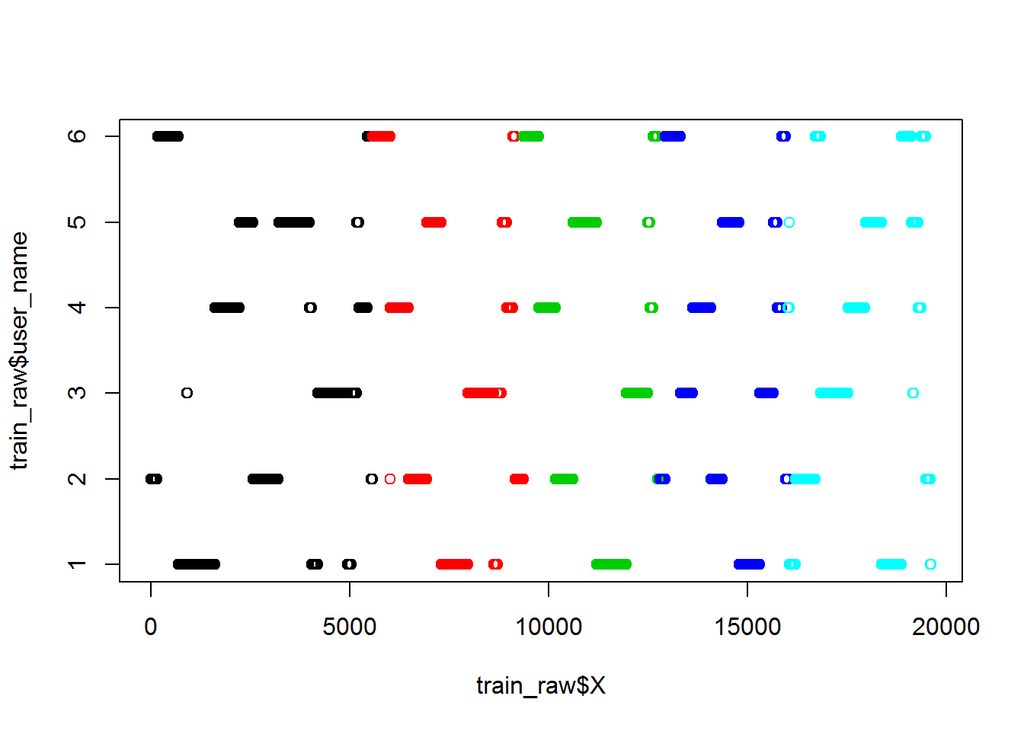

```r
plot(train_raw$X, train_raw$user_name, col=train_raw$classe)
```

From these observations, we preprocess the data by removing above-mentioned variables;

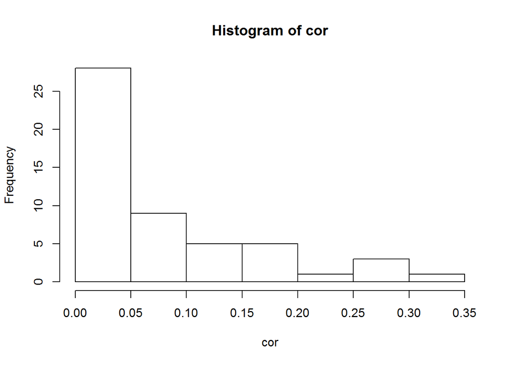

```r
# find near zero covariates
near_zero <- nearZeroVar(train_raw, saveMetrics = T)

# find variables with more than 90% missing values
miss_val <- sapply(colnames(train_raw), function(x) if(sum(is.na(train_raw[, x])) > 0.9*nrow(train_raw)){return(T)}else{return(F)})
remove_var <- miss_val|near_zero$nzv
training <- train_raw[, !remove_var]
# remove context variable (time related + user)
training <- training[,-c(1:6)]

# processing the testing set with the same procedure
testing <- test_raw[, !remove_var]
# remove remove context variable (time related + user)
testing <- testing[,-c(1:6)]

# calculate correlations
cor <- abs(sapply(colnames(training[, -ncol(training)]), function(x) cor(as.numeric(training[, x]), as.numeric(training$classe))))
hist(cor)
```

Since there is not strong correlation between predictors and outcome, linear model seems to be not suitable for this probelm. Therefore, we try 3 different classification algorithms: Decision Tree, Boosting and Random Forests for our data.

### Partition the data

Then, we can split the cleaned training set into a pure training data set (70%) and a validation data set (30%).

```r
set.seed(22519)
inTrain <- createDataPartition(training$classe, p=0.70, list=F)
train_df <- training[inTrain, ]
test_df <- training[-inTrain, ]
```

### Decision Tree model

We try to fit a simple tree model with 10-fold cross-validation to our data.

```r
# run the algorithm in parallel to reduce the execution time
library(foreach)
library(doParallel)
```

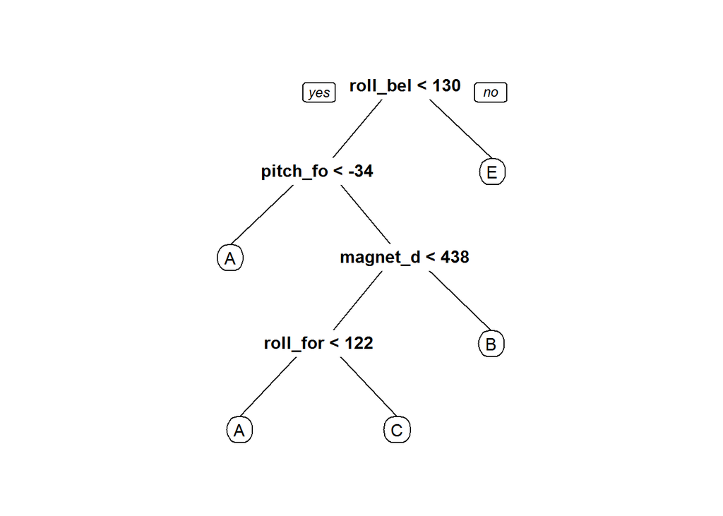

```r
registerDoParallel(cores=5)
set.seed(1987)
mod_tree <- train(classe~., data=train_df, method="rpart",trControl = trainControl(method = "cv", number = 10))
prp(mod_tree$finalModel) # fast plot
```

```r
pred_tree <- predict(mod_tree, test_df)
confusionMatrix(test_df$classe, pred_tree)
```

```
## Confusion Matrix and Statistics
##
##           Reference
## Prediction    A    B    C    D    E
##          A 1501   29  116    0   28
##          B  469  392  278    0    0
##          C  447   27  552    0    0
##          D  430  166  368    0    0
##          E  145  145  286    0  506
##
## Overall Statistics
##
##                Accuracy : 0.5014
##                  95% CI : (0.4886, 0.5143)
##     No Information Rate : 0.5084
##     P-Value [Acc > NIR] : 0.8604
##
##                   Kappa : 0.3494
##  Mcnemar's Test P-Value : NA
##
## Statistics by Class:
##
##                      Class: A Class: B Class: C Class: D Class: E
## Sensitivity            0.5017  0.51647   0.3450       NA  0.94757
## Specificity            0.9402  0.85427   0.8894   0.8362  0.89236
## Pos Pred Value         0.8967  0.34416   0.5380       NA  0.46765
## Neg Pred Value         0.6459  0.92267   0.7843       NA  0.99417
## Prevalence             0.5084  0.12897   0.2719   0.0000  0.09074
## Detection Rate         0.2551  0.06661   0.0938   0.0000  0.08598
## Detection Prevalence   0.2845  0.19354   0.1743   0.1638  0.18386
## Balanced Accuracy      0.7209  0.68537   0.6172       NA  0.91996
```

The Tree model is not a good option since the accuracy is just slightly better than random choice.

### Boosting model

- Build model with boosting algorithm and 10-fold cross validation to predict `classe` with all other predictors.
- Find the accuracy when applying to validation data set

```r
set.seed(1988)
mod_boost <- train(classe ~ ., method = "gbm", data = train_df, verbose = F, trControl = trainControl(method = "cv", number = 10))
pred_boost <- predict(mod_boost, test_df)
confusionMatrix(test_df$classe, pred_boost)
```

```
## Confusion Matrix and Statistics
##
##           Reference
## Prediction    A    B    C    D    E
##          A 1650   17    2    2    3
##          B   34 1075   26    4    0
##          C    0   23  996    7    0
##          D    0    0   43  913    8
##          E    5    9    8   18 1042
##
## Overall Statistics
##
##                Accuracy : 0.9645
##                  95% CI : (0.9594, 0.9691)
##     No Information Rate : 0.287
##     P-Value [Acc > NIR] : < 2.2e-16
##
##                   Kappa : 0.9551
##  Mcnemar's Test P-Value : 2.227e-09
##
## Statistics by Class:
##
##                      Class: A Class: B Class: C Class: D Class: E
## Sensitivity            0.9769   0.9564   0.9265   0.9672   0.9896
## Specificity            0.9943   0.9866   0.9938   0.9897   0.9917
## Pos Pred Value         0.9857   0.9438   0.9708   0.9471   0.9630
## Neg Pred Value         0.9907   0.9897   0.9837   0.9937   0.9977
## Prevalence             0.2870   0.1910   0.1827   0.1604   0.1789
## Detection Rate         0.2804   0.1827   0.1692   0.1551   0.1771
## Detection Prevalence   0.2845   0.1935   0.1743   0.1638   0.1839
## Balanced Accuracy      0.9856   0.9715   0.9601   0.9784   0.9906
```

- The Boosting algorithm has done a good classification job with the accuracy = 0.9645.

### Random forests model

- Since Random Forest is expected to be a good algorithm interm of accuracy, we try to apply it to our training data set with 10-fold cross validation. Then, we estimate the accuracy and out-of-sample error using validation set.

```r
set.seed(1998)
mod_rf <- train(classe ~ ., method = "rf", data = train_df, importance = T, trControl = trainControl(method = "cv", number = 10))

pred_rf <- predict(mod_rf, test_df)
confusionMatrix(test_df$classe, pred_rf)
```

```
## Confusion Matrix and Statistics
##
##           Reference
## Prediction    A    B    C    D    E
##          A 1674    0    0    0    0
##          B    3 1134    2    0    0
##          C    0    6 1020    0    0
##          D    0    0   26  937    1
##          E    0    0    0    5 1077
##
## Overall Statistics
##
##                Accuracy : 0.9927
##                  95% CI : (0.9902, 0.9947)
##     No Information Rate : 0.285
##     P-Value [Acc > NIR] : < 2.2e-16
##
##                   Kappa : 0.9908
##  Mcnemar's Test P-Value : NA
##
## Statistics by Class:
##
##                      Class: A Class: B Class: C Class: D Class: E
## Sensitivity            0.9982   0.9947   0.9733   0.9947   0.9991
## Specificity            1.0000   0.9989   0.9988   0.9945   0.9990
## Pos Pred Value         1.0000   0.9956   0.9942   0.9720   0.9954
## Neg Pred Value         0.9993   0.9987   0.9942   0.9990   0.9998
## Prevalence             0.2850   0.1937   0.1781   0.1601   0.1832
## Detection Rate         0.2845   0.1927   0.1733   0.1592   0.1830
## Detection Prevalence   0.2845   0.1935   0.1743   0.1638   0.1839
## Balanced Accuracy      0.9991   0.9968   0.9860   0.9946   0.9990
```

### Model selection and output

```r
# selected model
mod_rf$finalModel
```

```
##
## Call:
##  randomForest(x = x, y = y, mtry = param$mtry, importance = ..1)
##                Type of random forest: classification
##                      Number of trees: 500
## No. of variables tried at each split: 2
##
##         OOB estimate of  error rate: 0.67%
## Confusion matrix:
##      A    B    C    D    E  class.error
## A 3904    1    1    0    0 0.0005120328
## B   12 2641    5    0    0 0.0063957863
## C    0   19 2375    2    0 0.0087646077
## D    0    0   41 2209    2 0.0190941385
## E    0    0    3    6 2516 0.0035643564
```

```r
# final result for submission
prediction <- as.character(predict(mod_rf, testing))
prediction
```

```
##  [1] "B" "A" "B" "A" "A" "E" "D" "B" "A" "A" "B" "C" "B" "A" "E" "E" "A"
## [18] "B" "B" "B"
```

```r
# write prediction files
pml_write_files = function(x){
  n = length(x)
  for(i in 1:n){
    filename = paste0("./prediction/problem_id_", i, ".txt")
    write.table(x[i], file = filename, quote = FALSE, row.names = FALSE, col.names = FALSE)
  }
}
pml_write_files(prediction)
```